# Babynames Report

James P. Curley

October 17, 2017

#### Project Overview

In this project, I will analyze the data in the babynames package. The purpose of the tutorial is to provide examples of how to:

- use RMarkdown
- generate reproducible reports
- work with R projects with good folder structures
- source functions

### Loading The Data

```r
head(babynames)
```

```
## # A tibble: 6 x 5
##    year   sex      name     n       prop
##   <dbl> <chr>     <chr> <int>      <dbl>
## 1  1880     F      Mary  7065 0.07238433
## 2  1880     F      Anna  2604 0.02667923
## 3  1880     F      Emma  2003 0.02052170
## 4  1880     F Elizabeth  1939 0.01986599
## 5  1880     F    Minnie  1746 0.01788861
## 6  1880     F  Margaret  1578 0.01616737
```

This is the standard babynames package. It records the number of children born with each name in the USA for every year since 1880.

In total there are 1858689 observations. The years range from 1880 to 2015.

#### Sourcing Functions

What is going on here? Well, we are reading in the code in the R file `babynames_fns.R` using the function `readLines`. That is located in the `code` folder, which is one down from the main folder. But, because we’re working in the `manuscript` folder with this .Rmd file, we have to go up one level and then back down to the `code` folder. That’s why it looks this way: `../code`.

We can test whether this worked by trying to run a plot:

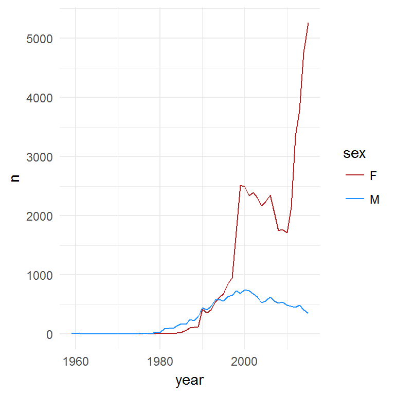

```r
name_plot("Skylar")
```

#### Reading in Data

Often you want to read in data from external sources. Here, I’m importing a list of names that are named after flowers, classic movie actresses or Broadway shows. We can just focus on the flower names.

```r
namesdf <- read.csv("../data/namelist.csv")
flowers <- namesdf[namesdf$type=="flower",]
as.character(flowers$name)
```

```
##  [1] "Amaryllis"     "Arcelia"       "Azalea"        "Begonia"
##  [5] "Blossom"       "Bluebell"      "Camelia"       "Chrysanthemum"
##  [9] "Daffodil"      "Dahlia"        "Daisy"         "Fiorella"
## [13] "Fleur"         "Flora"         "Forsythia"     "Fuchsia"
## [17] "Gardenia"      "Heather"       "Holly"         "Hyacinth"
## [21] "Iris"          "Ivy"           "Jasmine"       "Lavendar"
## [25] "Lilac"         "Lily"          "Lotus"         "Magnolia"
## [29] "Marigold"      "Myrtle"        "Narcissa"      "Oleander"
## [33] "Orchid"        "Pansy"         "Phlox"         "Poppy"
## [37] "Rose"          "Sunflower"     "Verbena"       "Violet"
```

#### Let’s look at the flower names

```r
babynames %>% filter(name %in% flowers$name) %>%
  group_by(name) %>% summarise(total = sum(n)) %>%
  arrange(total)
```

```
## # A tibble: 32 x 2
##             name total
##            <chr> <int>
##  1     Sunflower     6
##  2 Chrysanthemum    21
##  3       Verbena    98
##  4         Lilac   123
##  5         Fleur   160
##  6      Narcissa   190
##  7        Orchid   207
##  8      Marigold   292
##  9      Hyacinth   844
## 10      Fiorella   975
## # ... with 22 more rows
```

You can also place plots side by side like this adding `fig.show='hold'`:

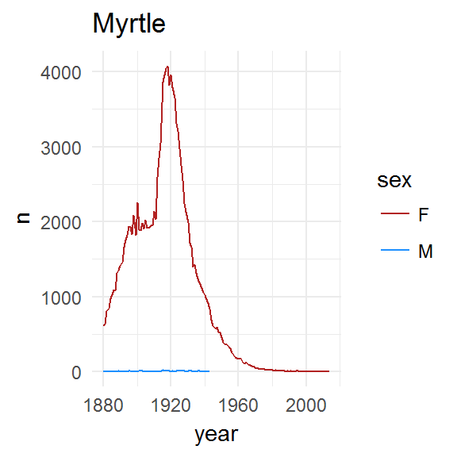

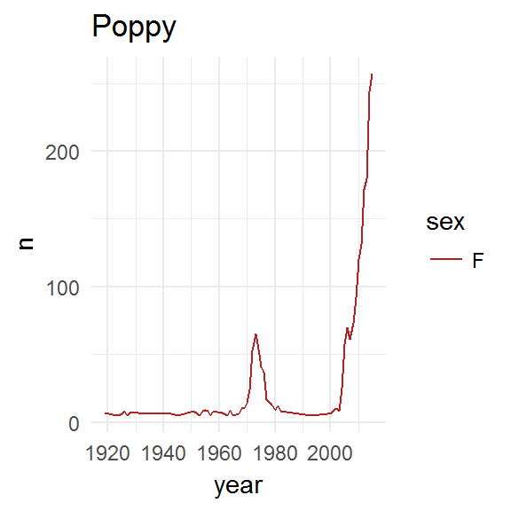

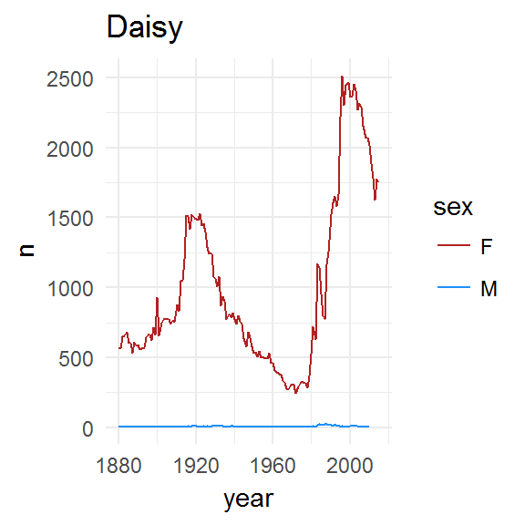

```r
name_plot("Myrtle") + ggtitle("Myrtle")
name_plot("Poppy") + ggtitle("Poppy")
name_plot("Daisy") + ggtitle("Daisy")
```

Daisy has a very interesting pattern - and here is a picture of a daisy:

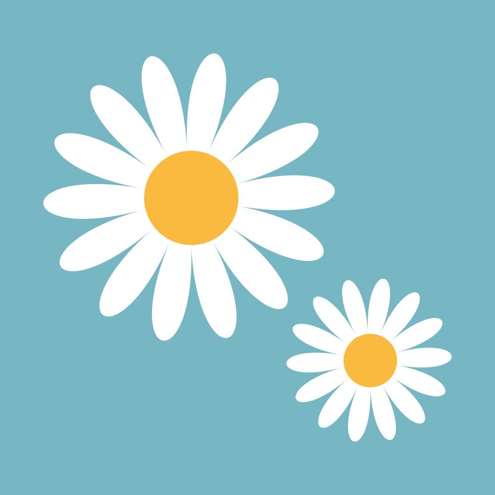

#### Names that don’t get used anymore

Another idea for analysis of this dataset might be to identify names that were used prior to WW2 but have never been used since. The following code creates two dataframes (pre + post) for each time period with the total number of names per era. Then we join them back together to identify those only used prior to WW2.

```r
pre <-
  babynames %>%
  filter(year<1945) %>%
  group_by(name) %>%
  summarize(total = sum(n)) %>%
  rename(npre = total)
```

```r
post <-
  babynames %>%
  filter(year>=1945) %>%
  group_by(name) %>%
  summarize(total = sum(n)) %>%
  rename(npost = total)
```

```r
head(pre)
```

```
## # A tibble: 6 x 2
##    name  npre
##   <chr> <int>
## 1  Aage     7
## 2 Aagot     5
## 3 Aarne    10
## 4 Aaron 21082
## 5    Ab    64
## 6   Abb    91
```

```r
head(post)
```

```
## # A tibble: 6 x 2
##        name npost
##       <chr> <int>
## 1     Aaban    87
## 2     Aabha    28
## 3     Aabid     5
## 4 Aabriella    15
## 5      Aada     5
## 6     Aadam   218
```

```r
ournames <- full_join(pre, post, by = "name")  #notice that some rows have "NA" - means they're missing (i.e. zeros)

ournames %>%
  filter(is.na(npost)==T) %>%
  arrange(desc(npre)) -> ournames_l

ournames_l
```

```
## # A tibble: 5,480 x 3
##        name  npre npost
##       <chr> <int> <int>
##  1  Mafalda  1279    NA
##  2  Gladyce  1006    NA
##  3   Vlasta   873    NA
##  4    Hideo   805    NA
##  5   Hildur   718    NA
##  6   Minoru   675    NA
##  7    Besse   671    NA
##  8  Shizuko   620    NA
##  9   Shizue   608    NA
## 10 Idabelle   596    NA
## # ... with 5,470 more rows
```

Whatever happened to Mafalda, Gladyce, Vlasta or Hideo?

Let’s look at the distribution of each of these in one graph….

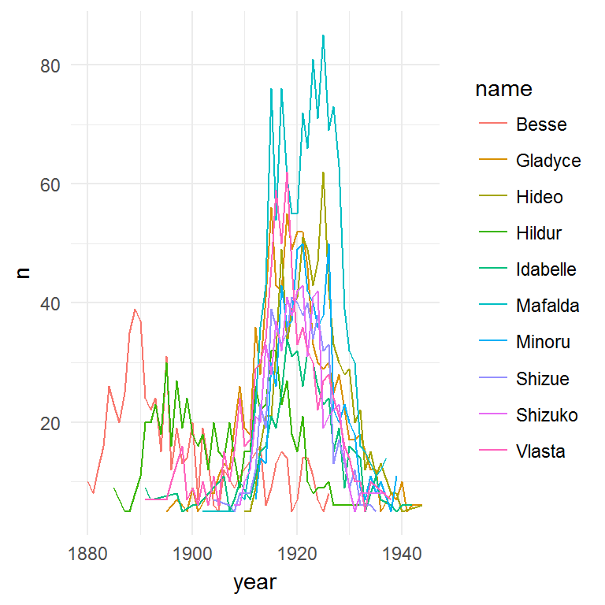

```r
#extact top 10 vanished names as a character vector
oldnames <- ournames_l[1:10,]$name

oldnames1 <- babynames %>%
  filter((name %in% oldnames ) == T)

ggplot(oldnames1, aes(year, n)) +
  geom_line(aes(group=name, color=name)) +
  theme_minimal()
```